# Apprentissage Statistique

Bank marketing

03 septembre, 2020

Abstract:

The data is related with direct marketing campaigns (based on phone calls) of a Portuguese banking institution. The aim of this project is to predict if a client will subscribe a term deposit (variable y). The dataset is constructed from 41188 observations which correspond to real customers recording. There are 21 variables which includes information about the client, the campaign and the economic context. The variable *y* is the target variable which indicates whether the customer has subscribed a term deposit or not. It appears that only a small proportion of our sample has subscribed a term deposit (11%, so the classes are not equally represented). Thus we are facing an issue of «imbalanced data».

# 1 Exploratory Data Analysis

```r
bank <- read.csv("https://raw.githubusercontent.com/lavergnetse/Data/master/bank-additional-full.csv", sep = ";",  stringsAsFactors = FALSE)
head(bank, 3)
```

```
##   age       job marital   education default housing loan   contact month
## 1  56 housemaid married    basic.4y      no      no   no telephone   may
## 2  57  services married high.school unknown      no   no telephone   may
## 3  37  services married high.school      no     yes   no telephone   may
##   day_of_week duration campaign pdays previous    poutcome emp.var.rate
## 1         mon      261        1   999        0 nonexistent          1.1
## 2         mon      149        1   999        0 nonexistent          1.1
## 3         mon      226        1   999        0 nonexistent          1.1
##   cons.price.idx cons.conf.idx euribor3m nr.employed  y
## 1         93.994         -36.4     4.857        5191 no
## 2         93.994         -36.4     4.857        5191 no
## 3         93.994         -36.4     4.857        5191 no
```

Let’s have a first overview of our dataset

```r
# Check the class
dplyr::glimpse(bank)
```

```
## Rows: 41,188
## Columns: 21
## $ age            <int> 56, 57, 37, 40, 56, 45, 59, 41, 24, 25, 41, 25, 29, 57…
## $ job            <chr> "housemaid", "services", "services", "admin.", "servic…
## $ marital        <chr> "married", "married", "married", "married", "married",…
## $ education      <chr> "basic.4y", "high.school", "high.school", "basic.6y", …
## $ default        <chr> "no", "unknown", "no", "no", "no", "unknown", "no", "u…
## $ housing        <chr> "no", "no", "yes", "no", "no", "no", "no", "no", "yes"…
## $ loan           <chr> "no", "no", "no", "no", "yes", "no", "no", "no", "no",…
## $ contact        <chr> "telephone", "telephone", "telephone", "telephone", "t…
## $ month          <chr> "may", "may", "may", "may", "may", "may", "may", "may"…
## $ day_of_week    <chr> "mon", "mon", "mon", "mon", "mon", "mon", "mon", "mon"…
## $ duration       <int> 261, 149, 226, 151, 307, 198, 139, 217, 380, 50, 55, 2…
## $ campaign       <int> 1, 1, 1, 1, 1, 1, 1, 1, 1, 1, 1, 1, 1, 1, 1, 1, 1, 1, …
## $ pdays          <int> 999, 999, 999, 999, 999, 999, 999, 999, 999, 999, 999,…
## $ previous       <int> 0, 0, 0, 0, 0, 0, 0, 0, 0, 0, 0, 0, 0, 0, 0, 0, 0, 0, …
## $ poutcome       <chr> "nonexistent", "nonexistent", "nonexistent", "nonexist…
## $ emp.var.rate   <dbl> 1.1, 1.1, 1.1, 1.1, 1.1, 1.1, 1.1, 1.1, 1.1, 1.1, 1.1,…
## $ cons.price.idx <dbl> 93.994, 93.994, 93.994, 93.994, 93.994, 93.994, 93.994…
## $ cons.conf.idx  <dbl> -36.4, -36.4, -36.4, -36.4, -36.4, -36.4, -36.4, -36.4…
## $ euribor3m      <dbl> 4.857, 4.857, 4.857, 4.857, 4.857, 4.857, 4.857, 4.857…
## $ nr.employed    <dbl> 5191, 5191, 5191, 5191, 5191, 5191, 5191, 5191, 5191, …
## $ y              <chr> "no", "no", "no", "no", "no", "no", "no", "no", "no", …
```

```r
# Check the statistical summary of each variables
summary(bank)
```

```
##       age            job              marital           education
##  Min.   :17.00   Length:41188       Length:41188       Length:41188
##  1st Qu.:32.00   Class :character   Class :character   Class :character
##  Median :38.00   Mode  :character   Mode  :character   Mode  :character
##  Mean   :40.02
##  3rd Qu.:47.00
##  Max.   :98.00
##    default            housing              loan             contact
##  Length:41188       Length:41188       Length:41188       Length:41188
##  Class :character   Class :character   Class :character   Class :character
##  Mode  :character   Mode  :character   Mode  :character   Mode  :character
##
##
##
##     month           day_of_week           duration         campaign
##  Length:41188       Length:41188       Min.   :   0.0   Min.   : 1.000
##  Class :character   Class :character   1st Qu.: 102.0   1st Qu.: 1.000
##  Mode  :character   Mode  :character   Median : 180.0   Median : 2.000
##                                        Mean   : 258.3   Mean   : 2.568
##                                        3rd Qu.: 319.0   3rd Qu.: 3.000
##                                        Max.   :4918.0   Max.   :56.000
##      pdays          previous       poutcome          emp.var.rate
##  Min.   :  0.0   Min.   :0.000   Length:41188       Min.   :-3.40000
##  1st Qu.:999.0   1st Qu.:0.000   Class :character   1st Qu.:-1.80000
##  Median :999.0   Median :0.000   Mode  :character   Median : 1.10000
##  Mean   :962.5   Mean   :0.173                      Mean   : 0.08189
##  3rd Qu.:999.0   3rd Qu.:0.000                      3rd Qu.: 1.40000
##  Max.   :999.0   Max.   :7.000                      Max.   : 1.40000
##  cons.price.idx  cons.conf.idx     euribor3m      nr.employed
##  Min.   :92.20   Min.   :-50.8   Min.   :0.634   Min.   :4964
##  1st Qu.:93.08   1st Qu.:-42.7   1st Qu.:1.344   1st Qu.:5099
##  Median :93.75   Median :-41.8   Median :4.857   Median :5191
##  Mean   :93.58   Mean   :-40.5   Mean   :3.621   Mean   :5167
##  3rd Qu.:93.99   3rd Qu.:-36.4   3rd Qu.:4.961   3rd Qu.:5228
##  Max.   :94.77   Max.   :-26.9   Max.   :5.045   Max.   :5228
##       y
##  Length:41188
##  Class :character
##  Mode  :character
##
##
##
```

## 1.1 Features

Related to the client:

- *Age*
- *Job*: ‘admin.’, ‘blue-collar’, ‘entrepreneur’, ‘housemaid’, ‘management’, ‘retired’, ‘self-employed’, ‘services’, ‘student’, ‘technician’, ‘unemployed’, ‘unknown’
- *Marital*: ‘divorced’, ‘married’, ‘single’, ‘unknown’
- *Education*: ‘basic.4y’, ‘basic.6y’, ‘basic.9y’, ‘high.school’, ‘illiterate’, ‘professional.course’, ‘university.degree’, ‘unknown’
- *Default*: has credit in default?
- *Housing*: has housing loan?
- *Loan*: has personal loan?

Related with the last contact of the current campaign:

- *Contact*: contact communication type
- *Month*: last contact month of year
- *Day_of_week*: last contact day of the week
- *Duration*: last contact duration in seconds

> *Important note*: this attribute highly affects the output target (e.g., if duration=0 then y=‘no’). Yet, the duration is not known before a call is performed. Also, after the end of the call y is obviously known. Thus, this input should only be included for benchmark purposes and should be discarded if the intention is to have a realistic predictive model.

Other attributes:

- *Campaign*: number of contacts performed during this campaign for this client
- *Pdays*: number of days that passed by after the client was last contacted from a previous campaign (999 means client was not previously contacted)
- *Previous*: number of contacts performed before this campaign
- *Poutcome*: outcome of the previous marketing campaign (‘failure’,‘nonexistent’,‘success’)

Social and economic context attributes:

- *Emp.var.rate*: employment variation rate - quarterly indicator
- *Cons.price.idx*: consumer price index - monthly indicator
- *Cons.conf.idx*: consumer confidence index - monthly indicator
- *Euribor3m*: euribor 3 month rate - daily indicator
- *Nr.employed*: number of employees - quarterly indicator

Finally our targeted variable:

- *y*: has the client subscribed a term deposit?

## 1.2 Imbalanced data

Regarding our output, the first thing we can observe is that we face an unbalanced two-levels categorical variable - that is, we have one class which outnumbers the other by a large proportion in the response variable:

```r
library(gmodels)
CrossTable(bank$y)
```

```
##
##
##    Cell Contents
## |-------------------------|
## |                       N |
## |         N / Table Total |
## |-------------------------|
##
##
## Total Observations in Table:  41188
##
##
##           |        no |       yes |
##           |-----------|-----------|
##           |     36548 |      4640 |
##           |     0.887 |     0.113 |
##           |-----------|-----------|
##
##
##
##
```

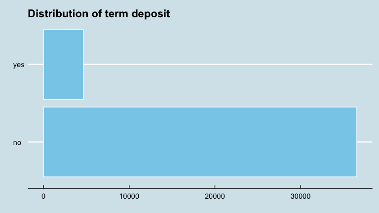

```r
# Plot the frequency
library(ggthemes)
ggplot(bank) + geom_bar(aes(y = y), colour="white", fill = "skyblue") +
  theme_economist() + labs(x = "", y = "") +
  ggtitle("Distribution of term deposit")
```

There is indeed 88.7% of “no” against only 11.3% of “yes”. This issue is common in binary classification problems, and do not consider this issue in the ML model could lead to a situation of «Accuracy paradox»: excellent accuracy (such as 90% of observations correctly classified), but which only reflecting the underlying class distribution. Hence, it is important to learn how to deal with such problems, and as you will see there are mainly two approaches to treat imbalanced data: Cost Sensitive Learning and resampling methods.

### 1.2.1 Cost Sensitive Learning

It is imperative to choose the evaluation metric of your model correctly. Indeed when dealing with imbalanced data, the accuracy (percentage of observations correctly classified) is no longer the indicator of interest: we will focus on other parameters. But first let’s define four fundamental terms:

- True Positives (TP): instance that is positive and is classified correctly as positive
- True Negatives (TN): instance that is negative and is classified correctly as negative
- False Positives (FP): instance that is negative but is classified wrongly as positive
- False Negatives (FN): instance that is positive but is classified incorrectly as negative

Depending on your work you may be interested by studying one or several of these category. A good model should have a high rate of correctly classified instances (TP & TN) and a low rate of incorrectly classified one (FP & FN). Thus when constructing the confusion matrix, alternative parameters such as **Precision**, **Sensitivity** and **Specificity** are useful.

Recall:

**Precision** is the number of positive predictions divided by the total number of positive class values predicted: `TP / (TP+FP)`. A low precision can thus indicate a large number of False Positives.

**Sensitivity** is the number of positive predictions divided by the number of positive class values : `TP / (TP+FN)`. A low sensitivity can thus indicate a large number of False Negatives.

**Specificity** is the number of negative predictions divided by the number of negative class values : `TN / (TN+FP)`.

There are also some other metrics that can be useful to see which model is the most efficient:

- *kappa*: give classification accuracy normalized by the imbalance of the classes in the data
- the ROC curve: show the performance of a classification model at all classification thresholds. It is one of the most used performance metrics. The curve is formed by plotting the sensitivity (benefits) and the specificity (costs). Thus, the larger the area under ROC curve, higher will be the accuracy.
- F1 score : $F1 = 2 \times \frac{precision \times sensitivity}{precision + sensitivity}$

The coefficient ranges from 0 to 1, where 1 means perfect precision & sensitivity.

### 1.2.2 Undersampling

This approach is part of the resampling methods, that involves modifying the initial dataset to create balanced data distribution. The undersampling consists to resample the dataset by deleting instances from the over-represented class. However, since this method involves removing observations, it is best to use with large dataset to limit information loss. There are two ways for deleting observations:

- by random undersampling: observations from majority class which are randomly eliminated until the data set gets balanced
- by informative undersampling: the deleted observations follows a pre-specified selection criterion

### 1.2.3 Oversampling

As you may have guessed, this method involves doing the reverse of the undersampling method. Hence it works with the minority class, and replicates the observations to balance the data. In the same way, oversampling can be done randomly or informatively.

However since it consists of simply adds replicated observations from the original dataset, it can increase the likelihood of overfitting.

### 1.2.4 Synthetic Data Generation

Instead of simply replicating and adding the observations from the minority class, the aim of this method is to balance class distribution by generating synthetic samples by using systematic algorithms such as SMOTE (Synthetic Minority Over-sampling Technique).

Unlike the previous oversampling method, the SMOTE algorithm generates artificial data based on feature space similarities from minority samples, and uses bootstrapping and k-nn. The minority class is thus over-sampled by introducing synthetic examples along the line segments joining any/all of the k minority class nearest neighbors. Depending upon the amount of over-sampling required, neighbors from the k nearest neighbors are randomly chosen.

We would therefore see some of these methods when we will create our training set. But first let’s prepare our data.

## 1.3 Data cleaning

### 1.3.1 Duplicated observations

```r
# See if the is any duplicated observations
sum(duplicated(bank))
```

```
## [1] 12
```

```r
# Eliminate all of them
bank <- unique(bank)
```

### 1.3.2 Missing values

There are «unknown» value in the dataset and we should consider these value as NA’s.

```r
sum(is.na(bank))
```

```
## [1] 0
```

```r
# Replace unknown by NA's
bank <- bank %>%
  mutate_all(~na_if(., 'unknown'))

# NA count
na_count <- as.data.frame(colSums(bank%>%is.na(.)))
na_count
```

```
##                colSums(bank %>% is.na(.))
## age                                     0
## job                                   330
## marital                                80
## education                            1730
## default                              8596
## housing                               990
## loan                                  990
## contact                                 0
## month                                   0
## day_of_week                             0
## duration                                0
## campaign                                0
## pdays                                   0
## previous                                0
## poutcome                                0
## emp.var.rate                            0
## cons.price.idx                          0
## cons.conf.idx                           0
## euribor3m                               0
## nr.employed                             0
## y                                       0
```

There are 12716 missing values in the dataset that are distributed among 6 features. Moreover we can see the an observation with NA’s for *loan* has also NA’s for *housing*, and conversely. Before deciding how to manage with those missing values, we will study the concerned features and take a decision after visualization. Indeed to keep the more information as possible, we will try to avoid simply eliminating rows with missing data (they represent almost 20% of our dataset), and will therefore proceed data imputation.

1. **Marital status & Job**

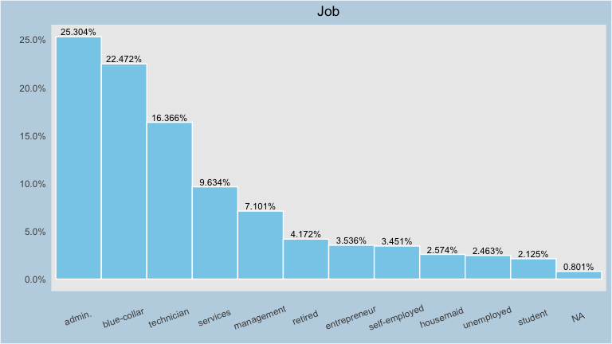

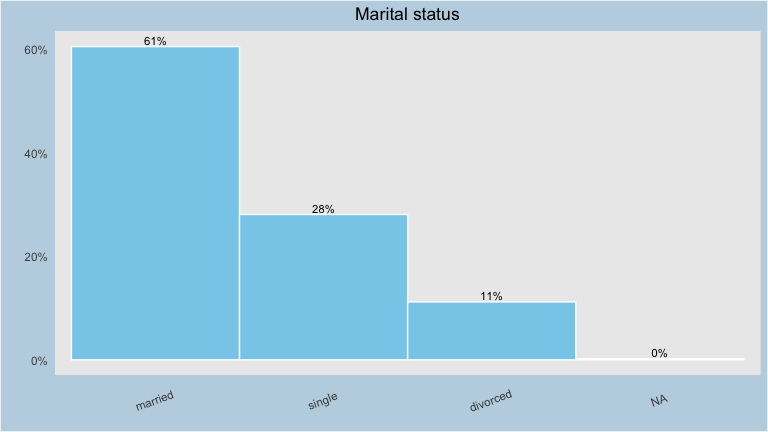

Given the small proportion of NA’s, we can simply remove them without causing any loss of information.

```r
bank <- bank[!is.na(bank$marital), ]
bank <- bank[!is.na(bank$job), ]
```

2. **Education level**

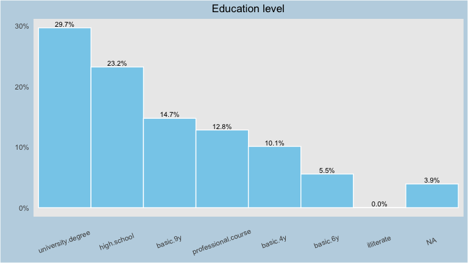

```r
#  Education level distribution
ggplot(bank, aes (x = fct_infreq(education))) +
    geom_bar(width = 1, colour = "white", fill="skyblue", show.legend = F,
             aes(y = ((..count..)/sum(..count..)))) +
    geom_text(aes(y = ((..count..)/sum(..count..)),
                  label = scales::percent((..count..)/sum(..count..))),
              stat = "count", size=3, vjust = -.3) +
    scale_y_continuous(labels = scales::percent) +
    theme + labs(x = "", y = "") +
    ggtitle("Education level")
```

```r
# First of all the illiterate category has not enough observations (18) so we can delete
# these observations

bank <- bank[!bank$education %in% "illiterate", ]
```

Now we can look at the link between the education level and the response variable:

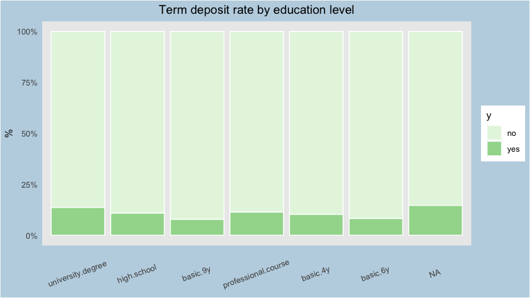

```r
ggplot(bank, aes(fct_infreq(education)), group=y) +
  geom_bar(aes(y = ..count../sum(..count..), fill = y),
           position = "fill", colour = "white") +
  theme + scale_fill_brewer(palette = "Greens") +
  scale_y_continuous(labels = scales::percent_format()) +
  labs(x = "", y = "%") +
  ggtitle("Term deposit rate by education level")
```

The NA category has the highest relative frequency, so we can make the hypothesis that those observations have a good education level. Indeed, “university.degree” has the second highest relative frequency.

```r
bank[is.na(bank$education),"education"] <- "university.degree"
```

3. **Default**

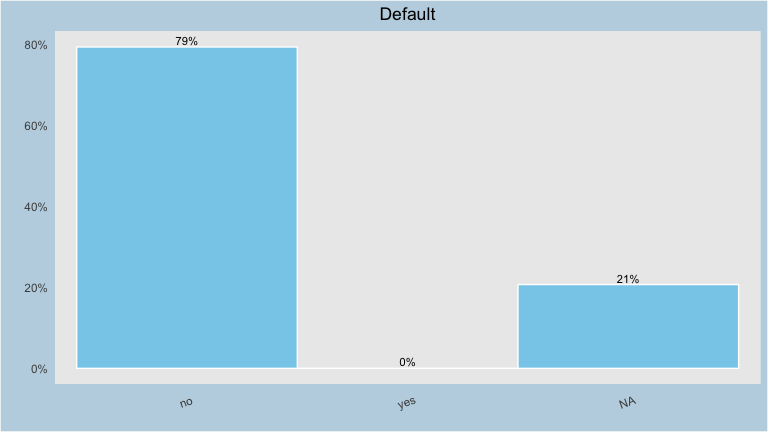

```r
bank <- bank[,!(names(bank) %in% c("default"))]
```

4. **Housing & loan**

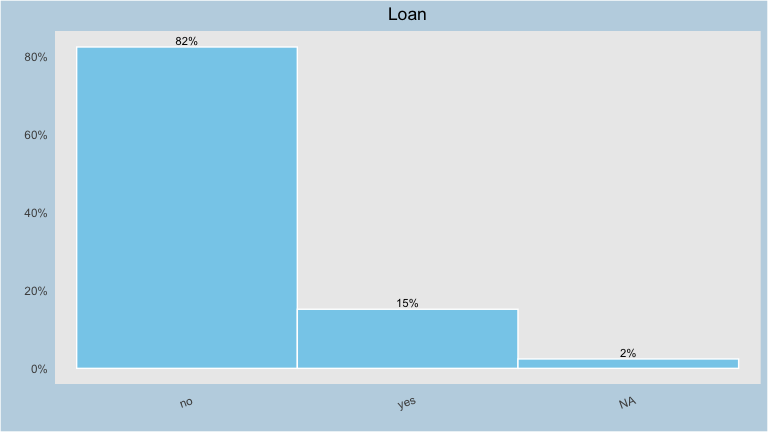

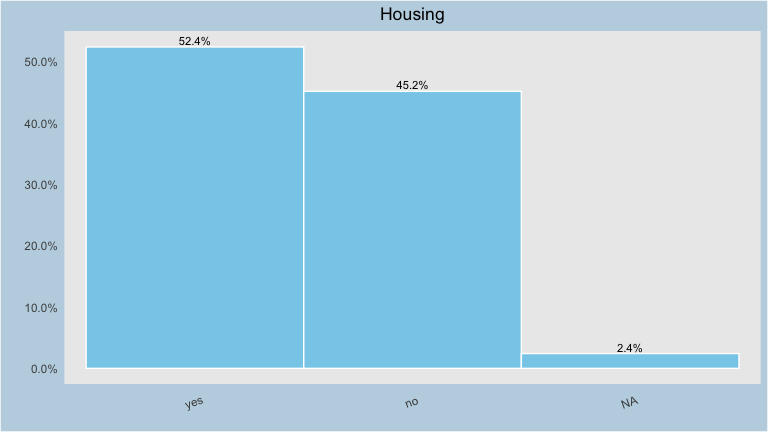

As we said before, there is the same number of NA’s for these two variables and it is also the same individuals. This let us think that there is a possible correlation link between the two variables that can cause multicolinearity issue.

```r
library(stats)
chisq.test(bank$loan, bank$housing)
```

```
##
##  Pearson's Chi-squared test with Yates' continuity correction
##
## data:  bank$loan and bank$housing
## X-squared = 84.622, df = 1, p-value < 2.2e-16
```

```r
chisq.test(bank$housing, bank$y)
```

```
##
##  Pearson's Chi-squared test with Yates' continuity correction
##
## data:  bank$housing and bank$y
## X-squared = 5.2924, df = 1, p-value = 0.02142
```

```r
chisq.test(bank$loan, bank$y)
```

```
##
##  Pearson's Chi-squared test with Yates' continuity correction
##
## data:  bank$loan and bank$y
## X-squared = 0.68594, df = 1, p-value = 0.4075
```

Regarding those test, we can see that the p-value associated to the Chi-squared test between “loan” and “y” equals to 0.4075, which is higher than a 0.01-threshold whereas the p-value associated to the Chi-squared test between “housing” and “y” equals to 0.021 which is lower 0.05. So, for a confidence level of 99%, there’s no association between “y” and “loan”. We thus remove this feature from the dataset:

```r
bank <- bank[,!(names(bank) %in% c("loan"))]
```

Now there still are 984 missing values for *housing* that we could replace by the median grouped by job, marital status and level of education. But for this exercise we will simply remove the missing values.

```r
# bank <- bank %>%
#   group_by(job,
#            marital,
#            education) %>%
#    mutate(housing=ifelse(is.na(housing),
#                           median(as.numeric(housing),na.rm=T),housing)) %>%
#   ungroup()
#
# bank$housing <- as.numeric(housing)
# bank$housing <- as.character(bank$housing)
#
# bank <- mutate(bank,
#                housing =  ifelse(housing=="1", "no", housing),
#                housing = ifelse(housing=="3", "yes", housing))

bank <- bank[!is.na(bank$housing),]
```

We finally control for NA’s

```r
sum(is.na(bank))
```

```
## [1] 0
```

### 1.3.3 Inconsistent values

First of all as recommended at the beginning of the project, we remove the feature *duration*:

```r
bank <- bank[,!(names(bank) %in% c("duration"))]
```

## 1.4 Data formating

### 1.4.1 Univariate analysis (creating subgroups & recoding)

#### 1.4.1.1 Categorical features

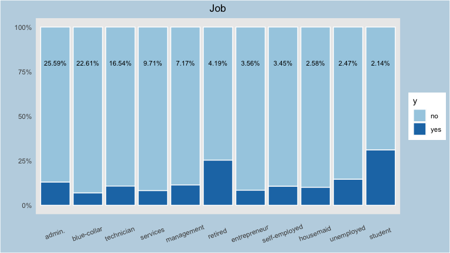

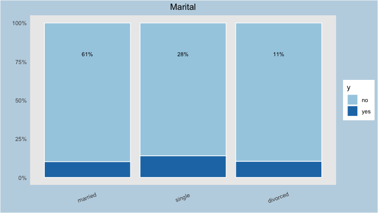

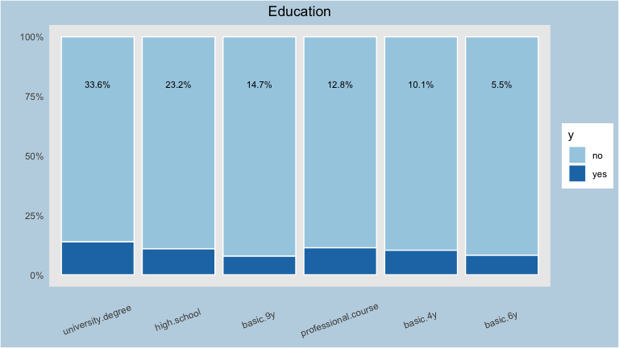

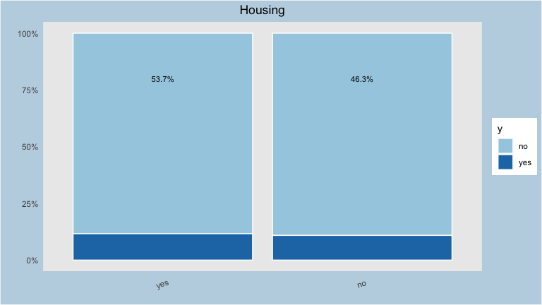

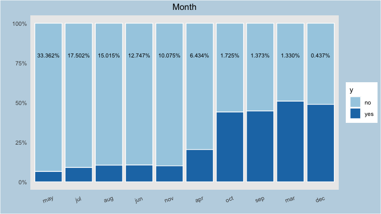

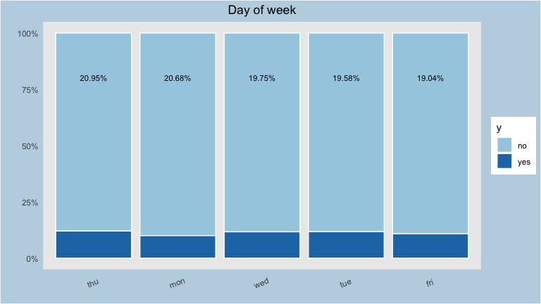

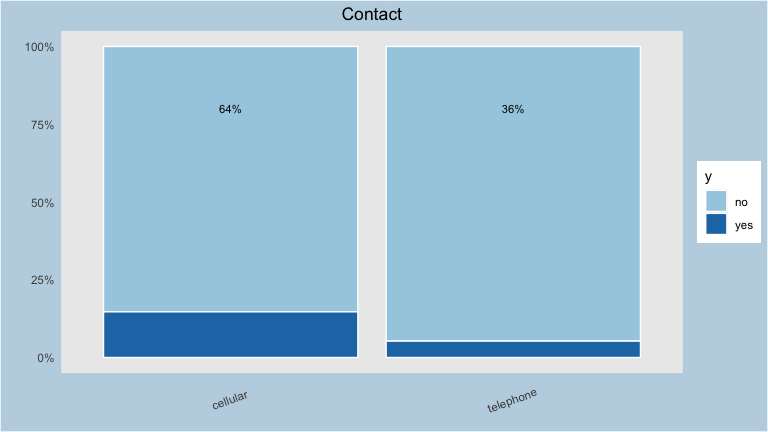

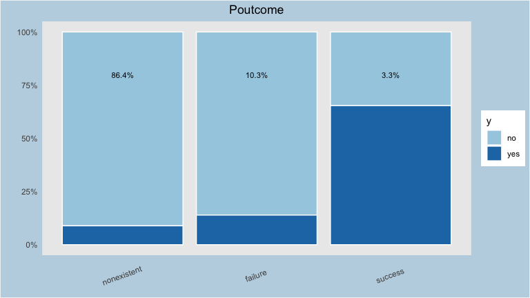

```r
features_categorical <- c("job", "marital", "education",
                          "housing", "month", "day_of_week",
                          "contact",  "poutcome")


for (i in features_categorical) {
  plot <- ggplot(bank,mapping = aes_string(x = fct_infreq(bank[,i])), group=y) +
    geom_bar(aes(y = ..count../sum(..count..), fill =y),
           position = "fill", colour = "white") +
    theme + scale_fill_brewer(palette = "Paired") +
    geom_text(aes(label=scales::percent(..count../sum(..count..))),
              stat='count', position=position_fill(vjust=0.8), size = 3) +
    labs(x = "", y = "") +
    scale_y_continuous(labels = scales::percent_format()) +
    ggtitle(str_replace_all(str_to_title(i), c("_" = " ")))
  print(plot)
}
```

```r
# The percentage showed on each bar represent the proportion of the value within the variable
```

We can create subgroups for *job* and *education*, and also recode as level both *month* and *day_of_week*.

- Subgroups for *job* and *education*:

```r
# # ===== ===== Education ===== =====

educ3 <- c("university.degree")

educ2 <- c("high.school","professional.course")

educ1 <- c("basic.4y","basic.6y", "basic.9y")


bank <- mutate(bank,
               education =  ifelse(education %in% educ1, "educ1",
                            ifelse(education %in% educ2, "educ2", "educ3")))


# # ===== ===== Job ===== =====

# Replace "-" by "_"
bank$job[bank$job == "blue-collar"] <- "blue_colar"
bank$job[bank$job == "self-employed"] <- "self_employed"
bank$job[bank$job == "admin."] <- "admin"

# voir pour les groupes:
#   - regrouper les personnes à leur comptes (entrepreneur, self-employed & housemaid)?
#   - blue-collar & technician ?
#   - admin., services & management?
```

- Recoding *month* and *day_of_week*:

```r
# # ===== ===== Month ===== =====

bank = bank %>%
  mutate(month = ifelse (month == "mar", "03",
                 ifelse (month == "apr", "04",
                 ifelse (month == "may", "05",
                 ifelse (month == "jun", "06",
                 ifelse (month == "jul", "07",
                 ifelse (month == "aug", "08",
                 ifelse (month == "sep", "09",
                 ifelse (month == "oct", "10",
                 ifelse (month == "nov", "11",
                 ifelse (month == "dec", "12", month)))))))))))


# # ===== ===== Days ===== =====

bank = bank %>%
  mutate(day_of_week = ifelse (day_of_week == "mon", "01",
                 ifelse (day_of_week == "tue", "02",
                 ifelse (day_of_week == "wed", "03",
                 ifelse (day_of_week == "thu", "04",
                 ifelse (day_of_week == "fri", "05", day_of_week))))))
```

Finally it will be better for prediction to recode *housing* & *contact*:

```r
# Housing
bank <- bank %>%
  mutate(housing = if_else(housing == "yes", "1", "0"))

# Contact
bank <- bank %>%
  mutate(contact = if_else(contact == "cellular", "1", "0"))

bank <- bank %>% rename(contact_cellular = contact)
```

#### 1.4.1.2 Discrete features

- *Age*

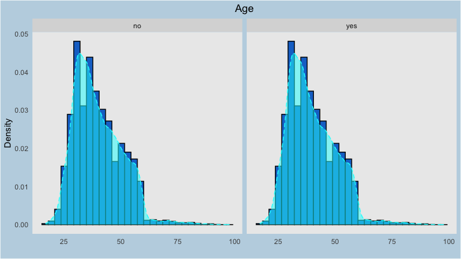

```r
ggplot(mapping = aes(x = bank$age)) +
  geom_histogram(colour="black", fill="dodgerblue3",
                 aes(y = ..density..)) + theme +
  ggtitle("Age") +
  labs(x = "", y = "Density") + facet_grid(~bank$y) +
  geom_density(fill = "cyan", colour = "cyan",
                 alpha = 0.5, lwd=0.5, linetype = "dashed")
```

Regarding the distribution of the age, we can see that the bank targets individuals aged between 25 and 60 years old. Moreover we can clearly distinguish 3 age group: (1) young under 30, (2) targeted population between 30-60 and (3) elder over 60

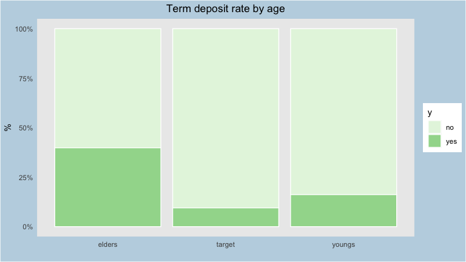

```r
bank <- bank %>%
  mutate(age = if_else(age < 30, "youngs",
                       if_else(age < 60, "target", "elders")))

ggplot(bank, aes(age), group=y) +
  geom_bar(aes(y = ..count../sum(..count..), fill = y),
           position = "fill", colour = "white") +
  theme + scale_fill_brewer(palette = "Greens") +
  scale_y_continuous(labels = scales::percent_format(accuracy = 1)) +
  labs(x = "", y = "%") +
  ggtitle("Term deposit rate by age")
```

- *Campaign*

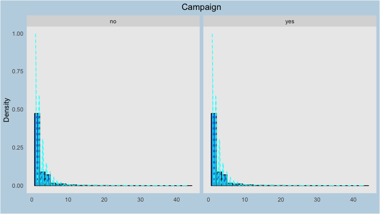

Calling a same person for a single marketing campaign more than 10 times seems to be too marginal. We can thus consider these observations as outliers and remove them.

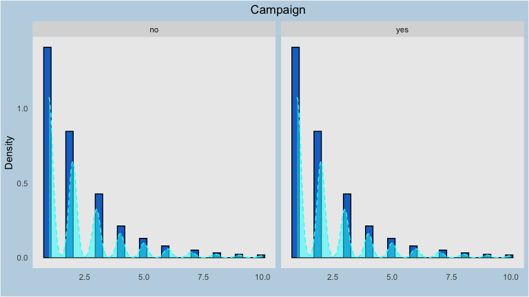

```r
bank <- bank %>% filter(campaign <= 10)

ggplot(mapping = aes(x = bank$campaign)) +
    geom_histogram(colour="black", fill="dodgerblue3",
                   aes(y = ..density..)) + theme +
    ggtitle("Campaign") +
    labs(x = "", y = "Density") + facet_grid(~bank$y) +
    geom_density(fill = "cyan", colour = "cyan",
                 alpha = 0.5, lwd=0.5, linetype = "dashed")
```

- *Pdays*

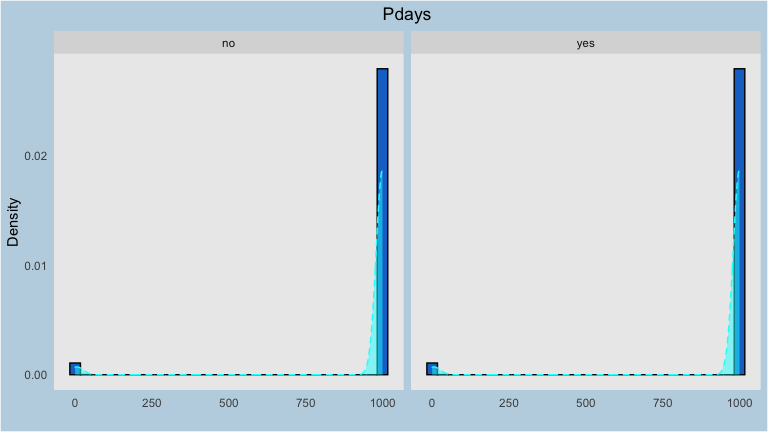

Intuitively by looking at the distribution of this feature (recall:it indicates the number of days that passed by after the client was last contacted from a previous campaign), we can create 2 subgroups: individuals who have been contacted before this campaign vs those who have never been contacted previously (pdays = 999)

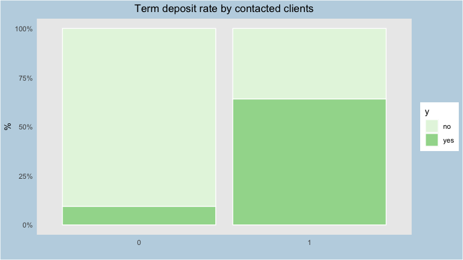

- *Previous*

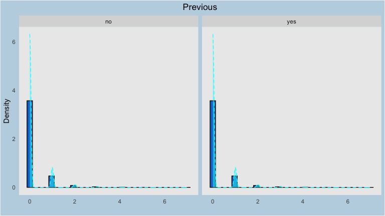

One more time we can create subgroups for this variable: (1) never contacted, (2) contacted once & (3) contacted more than once

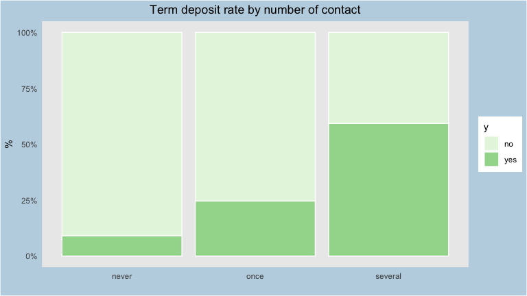

We have just created a dummy variable which indicates whether an individual has been contacted before or not. Then the variable «previous» indicates how many times this individual has been contacted before. Thus it seems to be an important correlation link between these two features.

```r
chisq.test(bank$pdays, bank$previous)
```

```
##
##  Pearson's Chi-squared test
##
## data:  bank$pdays and bank$previous
## X-squared = 11695, df = 2, p-value < 2.2e-16
```

### 1.4.2 Bivariate analysis

#### 1.4.2.1 Correlation between numerical features

For now we do not explore the distribution of our set of numeric features. Indeed we have just briefly explored these social and economic context attributes at the beginning by looking at their summary statistic, and we saw that is was not useful to study them in detail since they only give an evolution of external factors. However what we can study here is weather their evolution are correlated or not, an issue that we want to avoid. So let’s figure out this point:

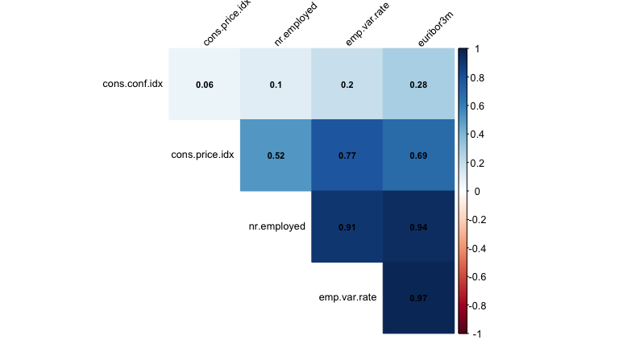

```r
# Correlation for numeric variables (except "campaign")
num_data <- select_if(bank[,-c(9)],is.numeric)

num_cor <- cor(num_data, method = "pearson")

# Correlogramme
corrplot(num_cor, method ="color", type="upper", order = "hclust",
         tl.col="black", addCoef.col = "black", number.cex = .7, tl.srt=45,
         tl.cex = 0.8, diag = FALSE)
```

We can observe that three pairs of features (*nr.employed* & *emp.var.rate*; *nr.employed* & *euribor3m*; *emp.var.rate* & *euribor3m*) present a high positive correlation (>0.9). As we know it can cause multicolinearity issue, and we thus have to remove some of these variables.

But first let’s make a little reminder regarding our variable *euribor3m*: the 3-month Euribor interest rate is the interest rate at which a selection of European banks lend each other funds (in euro), and whose loans have a maturity of 3 months. One can then ask ourselves what kind of correlation there could be with the evolution of the number of employees within the bank (*nr.employed* & *emp.var.rate*). Indeed the link does not seem obvious, and one could therefore make the hypothesis of a spurious correlation (e.g. there is no causal effect) between *euribor3m* and *emp.var.rate* / *nr.employed*.

However the relation between the employment variation rate (*emp.var.rate*) and the number of employees (*nr.employed*) appears obvious. So let’s see how these two features are correlated with our target variable.

Since *y* is a categorical variable with two levels (also called a dichotomous variable), with can use a point-biserial correlation (1) to estimate the relation, which is equivalent to the Pearson correlation (2). We will show you the two method:

```r
# === (1) Compute the point-biserial correlation ===
library(ltm)
biserial.cor(bank$emp.var.rate, bank$y, use = c("all.obs", "complete.obs"), level = 1)
```

```
## [1] 0.2962391
```

```r
biserial.cor(bank$nr.employed, bank$y, use = c("all.obs", "complete.obs"), level = 1)
```

```
## [1] 0.3528059
```

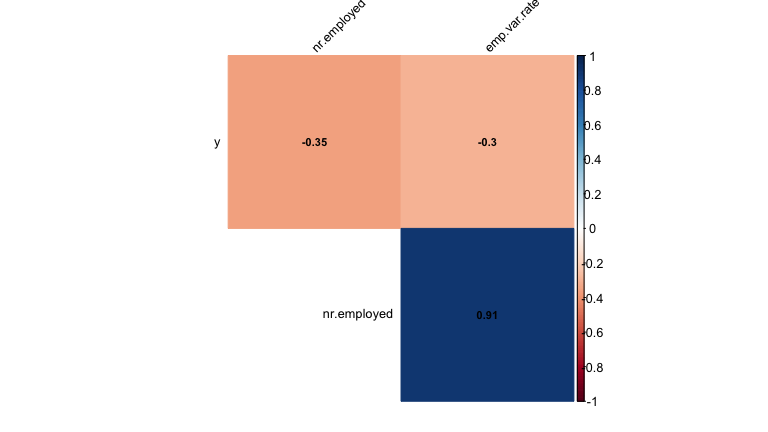

```r
# === (2) Create new data partition ===
interest_feature <- c("y", "nr.employed", "emp.var.rate")
mydata <- bank[,interest_feature]
mydata <- mydata %>% mutate(y = if_else(y == "yes", "1", "0"))
mydata$y <- as.numeric(mydata$y)

# Compute the Pearson correlation
biserial_cor <- cor(mydata, method = "pearson")

# Correlogramme
corrplot(biserial_cor, method ="color", type="upper", order = "hclust",
         tl.col="black", addCoef.col = "black", number.cex = .7, tl.srt=45,
         tl.cex = 0.8, diag = FALSE)
```

```r
# The variable "nr.employed" is the one with the higher correlation with y.
# We will therefore keep this one and remove the other.

bank <- bank[,!(names(bank) %in% c("emp.var.rate"))]
```

#### 1.4.2.2 Correlation between character features

In the same way we can have a look on the correlation with our other set of variables, and see if they show a dependency on each other. We will use **Cramer’s V** to study the different links. The Cramer’s V is computed as follow:

$$V = \sqrt{\frac{\chi^2}{n . \left( min\left(r, c \right) -1\right)}}$$

With: - $n$ the size of the sample - $r$ the number of rows in our contingency table - $c$ the number of columns in our contingency table

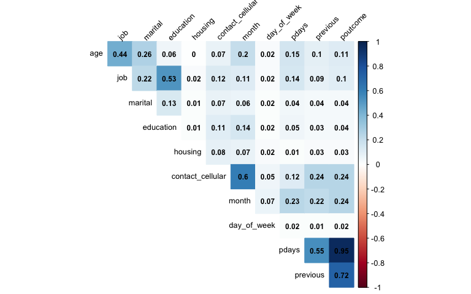

```r
# Data partition
chr_data <- select_if(bank[, -c(17)], ~is.character(.))

# Create contingency tables
cont_table <- matrix(NA, ncol(chr_data), ncol(chr_data))

for (i in (1:ncol(chr_data))){
  for (j in (1:ncol(chr_data))){
    x <- table(chr_data[, i], chr_data[, j])
    # Compute chi-square results
    chisq_results = chisq.test(x)
    # We compute the coefficients and keep only 3 digits
    cont_table[i, j] = round(sqrt(chisq_results$statistic/(nrow(chr_data) *
                                                          (min(dim(x)) -1))), 3)
  }
}

# We rename the rows and columns in the same way as a correlation matrix
rownames(cont_table) <- colnames(chr_data)
colnames(cont_table) <- colnames(chr_data)


# Correlogramme
corrplot(cont_table, method ="color", type="upper",
         tl.col="black", addCoef.col = "black", number.cex = .75, tl.srt=45,
         tl.cex = 0.8, diag = FALSE)
```

```r
# We create contingency tables
mytable1 <- table(bank$pdays, bank$y)
mytable2 <- table(bank$poutcome, bank$y)

library(rcompanion)
cramerV(mytable1)
```

```
## Cramer V
##   0.3255
```

```r
cramerV(mytable2)
```

```
## Cramer V
##   0.3209
```

Now we’ve done with all the pre-processing task, we can export our cleaned database before using it for the predictive models.

```r
write.csv(bank, "/Users/.../clean_bank.csv", row.names = FALSE)
```

# 2 Model prediction

## 2.1 Import and prepare the cleaned set

We import our cleaned data:

```r
bank_data <- read.csv("https://raw.githubusercontent.com/lavergnetse/Data/master/clean_bank.csv", sep = ",",  stringsAsFactors = TRUE)

str(bank_data)
```

```
## 'data.frame':    38936 obs. of  17 variables:
##  $ age             : Factor w/ 3 levels "elders","target",..: 2 2 2 2 2 2 2 2 3 3 ...
##  $ job             : Factor w/ 11 levels "admin","blue_colar",..: 4 8 8 1 8 8 1 2 10 8 ...
##  $ marital         : Factor w/ 3 levels "divorced","married",..: 2 2 2 2 2 2 2 2 3 3 ...
##  $ education       : Factor w/ 3 levels "educ1","educ2",..: 1 2 2 1 2 1 2 3 2 2 ...
##  $ housing         : int  0 0 1 0 0 0 0 0 1 1 ...
##  $ contact_cellular: int  0 0 0 0 0 0 0 0 0 0 ...
##  $ month           : int  5 5 5 5 5 5 5 5 5 5 ...
##  $ day_of_week     : int  1 1 1 1 1 1 1 1 1 1 ...
##  $ campaign        : int  1 1 1 1 1 1 1 1 1 1 ...
##  $ pdays           : int  0 0 0 0 0 0 0 0 0 0 ...
##  $ previous        : Factor w/ 3 levels "never","once",..: 1 1 1 1 1 1 1 1 1 1 ...
##  $ poutcome        : Factor w/ 3 levels "failure","nonexistent",..: 2 2 2 2 2 2 2 2 2 2 ...
##  $ cons.price.idx  : num  94 94 94 94 94 ...
##  $ cons.conf.idx   : num  -36.4 -36.4 -36.4 -36.4 -36.4 -36.4 -36.4 -36.4 -36.4 -36.4 ...
##  $ euribor3m       : num  4.86 4.86 4.86 4.86 4.86 ...
##  $ nr.employed     : num  5191 5191 5191 5191 5191 ...
##  $ y               : Factor w/ 2 levels "no","yes": 1 1 1 1 1 1 1 1 1 1 ...
```

Some variables are considered as integer instead of factor.

```r
int_feature <- c("month", "day_of_week")

for (i in int_feature){
  bank_data[,i] <- as.factor(bank_data[,i])
}

# Rename the feature y
colnames(bank_data)[which(names(bank_data) == "y")] <- "resp"

# Reverse the outcome to have 'yes' considered as positive
bank_data$resp <- factor(bank_data$resp, levels=rev(levels(bank_data$resp)))
```

### 2.1.1 Create dummies

```r
# Transform in a list the categorical features into dummies
dummies <- dummyVars(resp~., bank_data, sep = "_")

# Create a new dataset with the new dummy variables
new_set <- as.data.frame(predict(dummies, newdata = bank_data))

# Ad the column price in the new set
bank_model <- cbind(new_set,bank_data$resp)

# Rename the feature y
colnames(bank_model)[which(names(bank_model) == "bank_data$resp")] <- "resp"
```

### 2.1.2 Split the data (50/50)

```r
set.seed(777)

# Due to computing time issue, we will run the different models on only half of the data
trainIndex <- createDataPartition(bank_model$resp,
                                  p = .5,
                                  list = FALSE,
                                  times = 1)

bank_train <- bank_model[trainIndex,]
bank_test  <- bank_model[-trainIndex,]
```

We verify if the response variable balance between both splits:

```r
CrossTable(bank_train$resp)
```

```
##
##
##    Cell Contents
## |-------------------------|
## |                       N |
## |         N / Table Total |
## |-------------------------|
##
##
## Total Observations in Table:  19468
##
##
##           |       yes |        no |
##           |-----------|-----------|
##           |      2228 |     17240 |
##           |     0.114 |     0.886 |
##           |-----------|-----------|
##
##
##
##
```

```r
CrossTable(bank_test$resp)
```

```
##
##
##    Cell Contents
## |-------------------------|
## |                       N |
## |         N / Table Total |
## |-------------------------|
##
##
## Total Observations in Table:  19468
##
##
##           |       yes |        no |
##           |-----------|-----------|
##           |      2228 |     17240 |
##           |     0.114 |     0.886 |
##           |-----------|-----------|
##
##
##
##
```

### 2.1.3 Setting up the validation methods

```r
# function to set up random seeds
setSeeds <- function(method = "cv", numbers = 1, repeats = 1, tunes = NULL, seed = 1237) {
  #B is the number of resamples and integer vector of M (numbers + tune length if any)
  B <- if (method == "cv") numbers
  else if(method == "repeatedcv") numbers * repeats
  else NULL

  if(is.null(length)) {
    seeds <- NULL
  } else {
    set.seed(seed = seed)
    seeds <- vector(mode = "list", length = B)
    seeds <- lapply(seeds, function(x) sample.int(n = 1000000, size = numbers + ifelse(is.null(tunes), 0, tunes)))
    seeds[[length(seeds) + 1]] <- sample.int(n = 1000000, size = 1)
  }
  # return seeds
  seeds
}


# Seeds
rcvSeeds <- setSeeds(method = "repeatedcv",
                      numbers = 5, repeats = 5,
                      tunes = 100, seed = 777)

# Configure the trainControl argument for cross-validation
K5_CV <- trainControl(method = "cv", number = 5,
                      classProbs = TRUE,
                      savePredictions = TRUE,
                      seeds = rcvSeeds,
                      summaryFunction = twoClassSummary,
                      allowParallel = TRUE)
```

### 2.1.4 Allows for parallel computing

```r
# Detect the number of available cores and create cluster
library(parallel)
nrcore <- detectCores()
cl <- parallel::makeCluster(nrcore-1, setup_strategy = "sequential")

library(doParallel)
registerDoParallel(cl)
```

## 2.2 Logistic regression

### 2.2.1 Logit with imbalanced data

```r
set.seed(777)

logit <- train(resp ~ . - age_target -
                 job_admin -
                 marital_married -
                 education_educ1 -
                 month_3 -
                 day_of_week_1 -
                 previous_never -
                 poutcome_failure,
               data = bank_train, method = "glm",
               trControl = K5_CV)

summary(logit)
```

```
##
## Call:
## NULL
##
## Deviance Residuals:
##     Min       1Q   Median       3Q      Max
## -2.7736   0.2617   0.3327   0.3983   2.2405
##
## Coefficients: (1 not defined because of singularities)
##                        Estimate Std. Error z value Pr(>|z|)
## (Intercept)          -93.088962  31.930800  -2.915 0.003553 **
## age_elders            -0.245412   0.142553  -1.722 0.085152 .
## age_youngs            -0.036228   0.078692  -0.460 0.645245
## job_blue_colar         0.199498   0.097623   2.044 0.040998 *
## job_entrepreneur       0.044951   0.155941   0.288 0.773152
## job_housemaid          0.131185   0.187683   0.699 0.484568
## job_management         0.099685   0.108150   0.922 0.356672
## job_retired           -0.042579   0.146549  -0.291 0.771401
## job_self_employed     -0.042862   0.139173  -0.308 0.758099
## job_services           0.031720   0.104026   0.305 0.760426
## job_student           -0.259920   0.142889  -1.819 0.068907 .
## job_technician         0.061889   0.081620   0.758 0.448295
## job_unemployed        -0.059076   0.159570  -0.370 0.711218
## marital_divorced       0.021479   0.085811   0.250 0.802354
## marital_single        -0.020104   0.063809  -0.315 0.752713
## education_educ2       -0.025641   0.079666  -0.322 0.747562
## education_educ3       -0.125651   0.083279  -1.509 0.131349
## housing                0.074647   0.051277   1.456 0.145463
## contact_cellular      -0.549313   0.087801  -6.256 3.94e-10 ***
## month_4                0.768413   0.167312   4.593 4.38e-06 ***
## month_5                1.504292   0.152346   9.874  < 2e-16 ***
## month_6                0.463445   0.185182   2.503 0.012327 *
## month_7                0.651042   0.169324   3.845 0.000121 ***
## month_8                1.072679   0.168678   6.359 2.03e-10 ***
## month_9                1.522211   0.205244   7.417 1.20e-13 ***
## month_10               1.073487   0.193515   5.547 2.90e-08 ***
## month_11               1.283126   0.166609   7.701 1.35e-14 ***
## month_12               0.919488   0.269416   3.413 0.000643 ***
## day_of_week_2         -0.208777   0.082271  -2.538 0.011160 *
## day_of_week_3         -0.337957   0.081368  -4.153 3.27e-05 ***
## day_of_week_4         -0.254404   0.079005  -3.220 0.001282 **
## day_of_week_5         -0.164553   0.083764  -1.964 0.049474 *
## campaign               0.025885   0.016852   1.536 0.124522
## pdays                 -0.874894   0.264184  -3.312 0.000927 ***
## previous_once          0.486178   0.081753   5.947 2.73e-09 ***
## previous_several       0.680746   0.219334   3.104 0.001911 **
## poutcome_nonexistent         NA         NA      NA       NA
## poutcome_success      -0.992803   0.263283  -3.771 0.000163 ***
## cons.price.idx         0.214715   0.176107   1.219 0.222757
## cons.conf.idx         -0.013516   0.009987  -1.353 0.175950
## euribor3m             -0.205281   0.171562  -1.197 0.231486
## nr.employed            0.014527   0.003281   4.428 9.50e-06 ***
## ---
## Signif. codes:  0 '***' 0.001 '**' 0.01 '*' 0.05 '.' 0.1 ' ' 1
##
## (Dispersion parameter for binomial family taken to be 1)
##
##     Null deviance: 13850  on 19467  degrees of freedom
## Residual deviance: 10945  on 19427  degrees of freedom
## AIC: 11027
##
## Number of Fisher Scoring iterations: 6
```

Let’s see the performance of the model with the confusion matrix.

```r
logit_pred <- predict(logit, newdata = bank_test)

caret::confusionMatrix(data = logit_pred, reference = bank_test$resp,
                       positive="yes", mode = "everything")
```

```
## Confusion Matrix and Statistics
##
##           Reference
## Prediction   yes    no
##        yes   492   257
##        no   1736 16983
##
##                Accuracy : 0.8976
##                  95% CI : (0.8933, 0.9019)
##     No Information Rate : 0.8856
##     P-Value [Acc > NIR] : 4.14e-08
##
##                   Kappa : 0.2896
##
##  Mcnemar's Test P-Value : < 2.2e-16
##
##             Sensitivity : 0.22083
##             Specificity : 0.98509
##          Pos Pred Value : 0.65688
##          Neg Pred Value : 0.90726
##               Precision : 0.65688
##                  Recall : 0.22083
##                      F1 : 0.33053
##              Prevalence : 0.11444
##          Detection Rate : 0.02527
##    Detection Prevalence : 0.03847
##       Balanced Accuracy : 0.60296
##
##        'Positive' Class : yes
##
```

### 2.2.2 Logit with SMOTE

At the beginning of the project we spoke about the different issues that can arise when dealing with imbalanced data and we mentioned some ways to avoid this trap.

In what follows, we will approach the oversampling method with the SMOTE algorithm, and we will thus create extra positive observations. Then we will compare the results obtained from each of these two sets.

```r
set.seed(777)

K5_CV$sampling <- "smote"

logit2 <- train(resp ~ . - age_target -
                 job_admin -
                 marital_married -
                 education_educ1 -
                 month_3 -
                 day_of_week_1 -
                 previous_never -
                 poutcome_failure,
               data = bank_train,
               method = "glm",
               trControl = K5_CV)

logit2_pred <- predict(logit2, newdata = bank_test)

caret::confusionMatrix(data = logit2_pred, reference = bank_test$resp,
                       positive="yes", mode = "everything")
```

```
## Confusion Matrix and Statistics
##
##           Reference
## Prediction   yes    no
##        yes  1319  2068
##        no    909 15172
##
##                Accuracy : 0.8471
##                  95% CI : (0.8419, 0.8521)
##     No Information Rate : 0.8856
##     P-Value [Acc > NIR] : 1
##
##                   Kappa : 0.3849
##
##  Mcnemar's Test P-Value : <2e-16
##
##             Sensitivity : 0.59201
##             Specificity : 0.88005
##          Pos Pred Value : 0.38943
##          Neg Pred Value : 0.94347
##               Precision : 0.38943
##                  Recall : 0.59201
##                      F1 : 0.46981
##              Prevalence : 0.11444
##          Detection Rate : 0.06775
##    Detection Prevalence : 0.17398
##       Balanced Accuracy : 0.73603
##
##        'Positive' Class : yes
##
```

But does it change something about the coefficients?

```r
summary(logit2)
```

```
##
## Call:
## NULL
##
## Deviance Residuals:
##     Min       1Q   Median       3Q      Max
## -2.1638  -0.7819   0.5860   0.8009   3.0694
##
## Coefficients: (1 not defined because of singularities)
##                        Estimate Std. Error z value Pr(>|z|)
## (Intercept)          -82.477639  26.886913  -3.068 0.002158 **
## age_elders            -0.033343   0.131375  -0.254 0.799652
## age_youngs             0.086668   0.062065   1.396 0.162593
## job_blue_colar         0.242859   0.072561   3.347 0.000817 ***
## job_entrepreneur       0.219754   0.116253   1.890 0.058717 .
## job_housemaid          0.532091   0.150303   3.540 0.000400 ***
## job_management         0.312296   0.085177   3.666 0.000246 ***
## job_retired           -0.007856   0.123958  -0.063 0.949465
## job_self_employed      0.195032   0.113422   1.720 0.085519 .
## job_services           0.138556   0.078594   1.763 0.077912 .
## job_student           -0.235618   0.128252  -1.837 0.066188 .
## job_technician         0.145102   0.063822   2.274 0.022993 *
## job_unemployed         0.263210   0.135906   1.937 0.052780 .
## marital_divorced       0.154965   0.068000   2.279 0.022673 *
## marital_single        -0.031812   0.048974  -0.650 0.515967
## education_educ2        0.046807   0.061063   0.767 0.443359
## education_educ3       -0.118781   0.065579  -1.811 0.070098 .
## housing                0.080111   0.039516   2.027 0.042629 *
## contact_cellular      -0.673193   0.076269  -8.827  < 2e-16 ***
## month_4                1.132726   0.171220   6.616 3.70e-11 ***
## month_5                1.862256   0.160758  11.584  < 2e-16 ***
## month_6                0.765073   0.204127   3.748 0.000178 ***
## month_7                1.095436   0.178948   6.122 9.27e-10 ***
## month_8                1.520027   0.185029   8.215  < 2e-16 ***
## month_9                1.991353   0.215499   9.241  < 2e-16 ***
## month_10               1.023411   0.207870   4.923 8.51e-07 ***
## month_11               1.739653   0.167629  10.378  < 2e-16 ***
## month_12               1.682655   0.274259   6.135 8.50e-10 ***
## day_of_week_2         -0.050710   0.062942  -0.806 0.420439
## day_of_week_3         -0.282654   0.061680  -4.583 4.59e-06 ***
## day_of_week_4         -0.113898   0.060821  -1.873 0.061113 .
## day_of_week_5         -0.047066   0.063846  -0.737 0.461012
## campaign               0.029349   0.012558   2.337 0.019436 *
## pdays                 -1.466862   0.357817  -4.099 4.14e-05 ***
## previous_once          0.470663   0.066600   7.067 1.58e-12 ***
## previous_several       1.019662   0.242631   4.203 2.64e-05 ***
## poutcome_nonexistent         NA         NA      NA       NA
## poutcome_success      -0.438757   0.361511  -1.214 0.224871
## cons.price.idx         0.104183   0.151480   0.688 0.491598
## cons.conf.idx         -0.028867   0.009937  -2.905 0.003673 **
## euribor3m             -0.168152   0.142510  -1.180 0.238027
## nr.employed            0.013883   0.002758   5.034 4.81e-07 ***
## ---
## Signif. codes:  0 '***' 0.001 '**' 0.01 '*' 0.05 '.' 0.1 ' ' 1
##
## (Dispersion parameter for binomial family taken to be 1)
##
##     Null deviance: 21301  on 15595  degrees of freedom
## Residual deviance: 16382  on 15555  degrees of freedom
## AIC: 16464
##
## Number of Fisher Scoring iterations: 5
```

A lot of features are non-significant in both models, although there are more significant coefficients in the second one. In consequence we will drop some of them to improve the performances.

```r
set.seed(777)


K5_CV <- trainControl(method = "cv", number = 5, classProbs = TRUE,
                           savePredictions = TRUE, seeds = rcvSeeds,
                           allowParallel = TRUE, summaryFunction = twoClassSummary,
                           sampling = "smote")


logit3 <- train(resp ~ . - age_target -
                 job_admin -
                 marital_married -
                 education_educ1 -
                 month_3 -
                 day_of_week_1 -
                 previous_never -
                 poutcome_failure -
                 marital_divorced -
                 marital_single -
                 cons.price.idx -
                 euribor3m,
               data = bank_train,
               method = "glm",
               trControl = K5_CV)

logit3
```

```
## Generalized Linear Model
##
## 19468 samples
##    49 predictor
##     2 classes: 'yes', 'no'
##
## No pre-processing
## Resampling: Cross-Validated (5 fold)
## Summary of sample sizes: 15575, 15574, 15575, 15574, 15574
## Addtional sampling using SMOTE
##
## Resampling results:
##
##   ROC        Sens       Spec
##   0.7825024  0.5906464  0.8774942
```

```r
# Model performances
logit_pred <- predict(logit3, newdata = bank_test)

confus_logit <- confusionMatrix(data = logit_pred, reference = bank_test$resp,
                       positive="yes", mode = "everything")

confus_logit
```

```
## Confusion Matrix and Statistics
##
##           Reference
## Prediction   yes    no
##        yes  1308  2073
##        no    920 15167
##
##                Accuracy : 0.8463
##                  95% CI : (0.8411, 0.8513)
##     No Information Rate : 0.8856
##     P-Value [Acc > NIR] : 1
##
##                   Kappa : 0.381
##
##  Mcnemar's Test P-Value : <2e-16
##
##             Sensitivity : 0.58707
##             Specificity : 0.87976
##          Pos Pred Value : 0.38687
##          Neg Pred Value : 0.94281
##               Precision : 0.38687
##                  Recall : 0.58707
##                      F1 : 0.46639
##              Prevalence : 0.11444
##          Detection Rate : 0.06719
##    Detection Prevalence : 0.17367
##       Balanced Accuracy : 0.73341
##
##        'Positive' Class : yes
##
```

We know have a parsimonious model, so let’s see which variables have the biggest impact in the predictions :

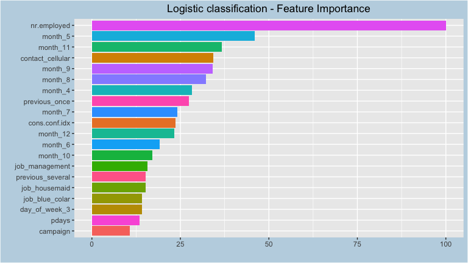

```r
logit_varImp <- data.frame(variables = row.names(varImp(logit3)$importance),
                             varImp(logit3)$importance)

logit_varImp <- logit_varImp[order(-logit_varImp$Overall),]

theme_model <- theme(plot.title = element_text(hjust = 0.5),
               plot.background = element_rect(fill = "#BFD5E3"),
               legend.position = "none")

ggplot(data = logit_varImp[1:20,], mapping = aes(x=reorder(variables, Overall),
                                            y=Overall, fill=variables)) +
  coord_flip() + geom_bar(stat = "identity", position = "dodge") +
  theme_model + labs(x = "", y = "") +
  ggtitle("Logistic classification - Feature Importance")
```

## 2.3 Linear Discriminant Analysis

```r
set.seed(777)

K5_CV <- trainControl(method = "cv", number = 5, classProbs = TRUE,
                           savePredictions = TRUE, seeds = rcvSeeds,
                           allowParallel = TRUE, summaryFunction =  twoClassSummary,
                           sampling = "smote")

# Model
lda <- train(resp ~ .,
             data = bank_train,
             method = "lda",
             trControl = K5_CV)

lda
```

```
## Linear Discriminant Analysis
##
## 19468 samples
##    49 predictor
##     2 classes: 'yes', 'no'
##
## No pre-processing
## Resampling: Cross-Validated (5 fold)
## Summary of sample sizes: 15575, 15574, 15575, 15574, 15574
## Addtional sampling using SMOTE
##
## Resampling results:
##
##   ROC        Sens       Spec
##   0.7815528  0.5951338  0.8759861
```

```r
# Model performances
lda_pred <- predict(lda, newdata = bank_test)

confus_lda <- confusionMatrix(data = lda_pred, reference = bank_test$resp,
                       positive="yes", mode = "everything")

confus_lda
```

```
## Confusion Matrix and Statistics
##
##           Reference
## Prediction   yes    no
##        yes  1328  2127
##        no    900 15113
##
##                Accuracy : 0.8445
##                  95% CI : (0.8393, 0.8496)
##     No Information Rate : 0.8856
##     P-Value [Acc > NIR] : 1
##
##                   Kappa : 0.3813
##
##  Mcnemar's Test P-Value : <2e-16
##
##             Sensitivity : 0.59605
##             Specificity : 0.87662
##          Pos Pred Value : 0.38437
##          Neg Pred Value : 0.94380
##               Precision : 0.38437
##                  Recall : 0.59605
##                      F1 : 0.46736
##              Prevalence : 0.11444
##          Detection Rate : 0.06821
##    Detection Prevalence : 0.17747
##       Balanced Accuracy : 0.73634
##
##        'Positive' Class : yes
##
```

## 2.4 Decision tree

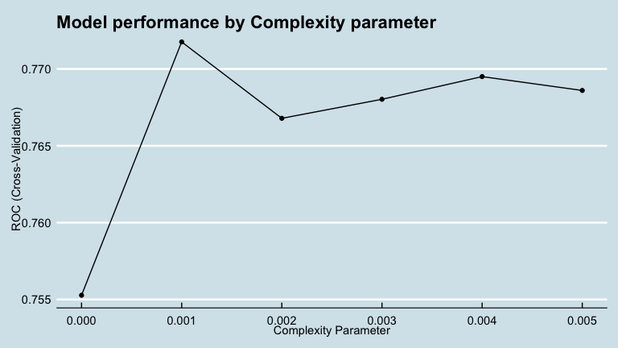

```r
# set.seed(777)
#
# K5_CV <- trainControl(method = "cv", number = 5, classProbs = TRUE,
#                            savePredictions = TRUE, seeds = rcvSeeds,
#                            allowParallel = TRUE, summaryFunction = twoClassSummary,
#                       sampling = "smote")
#
# # Parameter tuning
# grid <- expand.grid(cp = seq(from = 0, to = 0.005, by = 0.001))
#
# # Model
# DTree_tune <- train(resp ~ .,
#                data = bank_train,
#                method = "rpart",
#                tuneGrid = grid,
#                trControl = K5_CV)
#
# saveRDS(DTree_tune, "/Users/.../DTree_tune.rds")


githubURL <- "https://raw.githubusercontent.com/lavergnetse/Data/master/DTree_tune.rds"
DTree_tune <- readRDS(url(githubURL))

ggplot(DTree_tune) +
  theme_economist() +
  ggtitle("Model performance by Complexity parameter")
```

```r
set.seed(777)

K5_CV <- trainControl(method = "cv", number = 5, classProbs = TRUE,
                           savePredictions = TRUE, seeds = rcvSeeds,
                           allowParallel = TRUE, summaryFunction = twoClassSummary,
                           sampling = "smote")

# Parameter tuning
grid <- expand.grid(cp = .001)

# Model
DTree <- train(resp ~ .,
               data = bank_train,
               method = "rpart",
               tuneGrid = grid,
               trControl = K5_CV)

# Model performances
DTree_pred <- predict(DTree, newdata = bank_test)

confus_DTree <- confusionMatrix(data = DTree_pred, reference = bank_test$resp,
                       positive="yes", mode = "everything")

confus_DTree
```

```
## Confusion Matrix and Statistics
##
##           Reference
## Prediction   yes    no
##        yes  1269  1660
##        no    959 15580
##
##                Accuracy : 0.8655
##                  95% CI : (0.8606, 0.8702)
##     No Information Rate : 0.8856
##     P-Value [Acc > NIR] : 1
##
##                   Kappa : 0.4163
##
##  Mcnemar's Test P-Value : <2e-16
##
##             Sensitivity : 0.56957
##             Specificity : 0.90371
##          Pos Pred Value : 0.43325
##          Neg Pred Value : 0.94202
##               Precision : 0.43325
##                  Recall : 0.56957
##                      F1 : 0.49215
##              Prevalence : 0.11444
##          Detection Rate : 0.06518
##    Detection Prevalence : 0.15045
##       Balanced Accuracy : 0.73664
##
##        'Positive' Class : yes
##
```

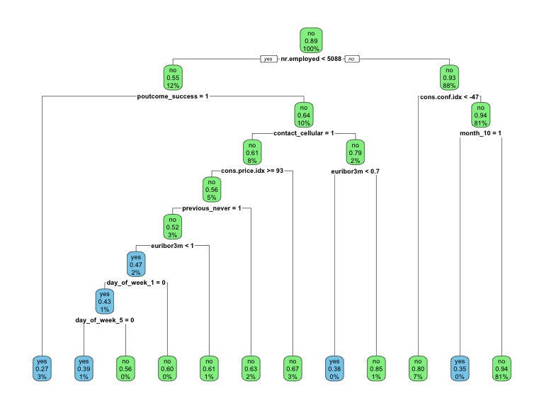

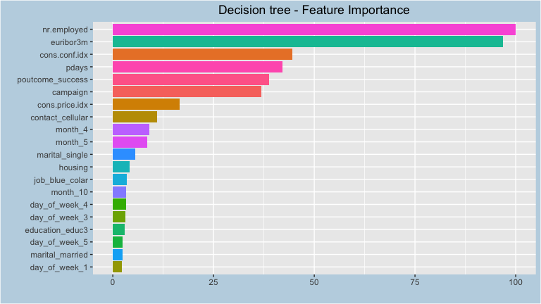

```r
library(rpart)
DTree_plot = rpart(resp ~ .,
             data = bank_train,
             cp = 0.002)

library(rpart.plot)
rpart.plot(DTree_plot, box.palette=c("skyblue", "lightgreen"))
```